# TDDE07 - Lab 2

Pontus Svensson (ponsv690) & Kristian Sikiric (krisi211)

# Assignment 1

### Normal model, mixture of normal model with semi-conjugate prior

In this assignment a data file containing the daily precepitation from year 1948 to 1983 was given. We were to analyze this data using two different models using gibbs sampling. The daily precipitation ${y_1,...,y_n}$ were assumed to be independently normal distributed, $y_1,..y_n|\mu,\sigma^2 \sim \mathcal{N}(\mu,\sigma^2)$ were $\mu \sim \mathcal{N}(\mu_0,\tau_0^2)$ and $\sigma \sim Inv-\mathcal{X}^2(\nu_0,\sigma_0^2)$. Since there are two random variables, we have a bivariate normal distribution.

The full conditional posteriors were given to be $\mu|\sigma^2,x \sim \mathcal{N}(\mu_n,\tau_n^2)$ and $\sigma^2|\mu,x \sim Inv-\mathcal{X}(\nu_n,\frac{\nu_0\sigma_0^2 + \sum_{i=1}^n(x_i-\mu)^2)}{n+\nu_0})$

Now we could use these to implement a gibbs sampler, the initial varables were set to some random values based on our priors, (see code). The following histogram shows the result after sampling.

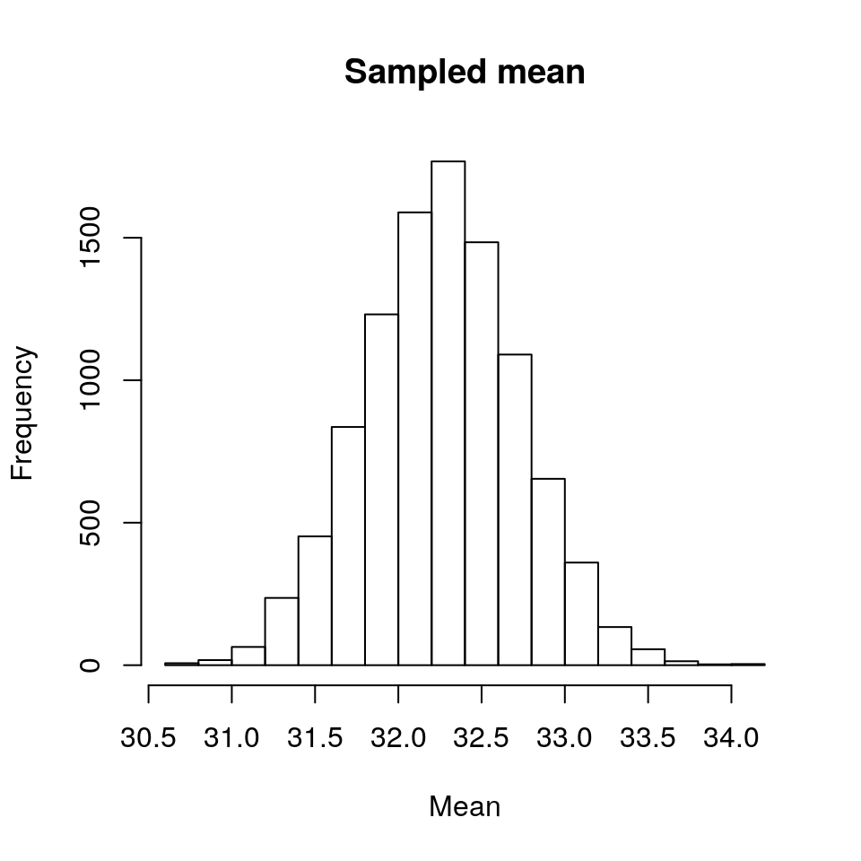

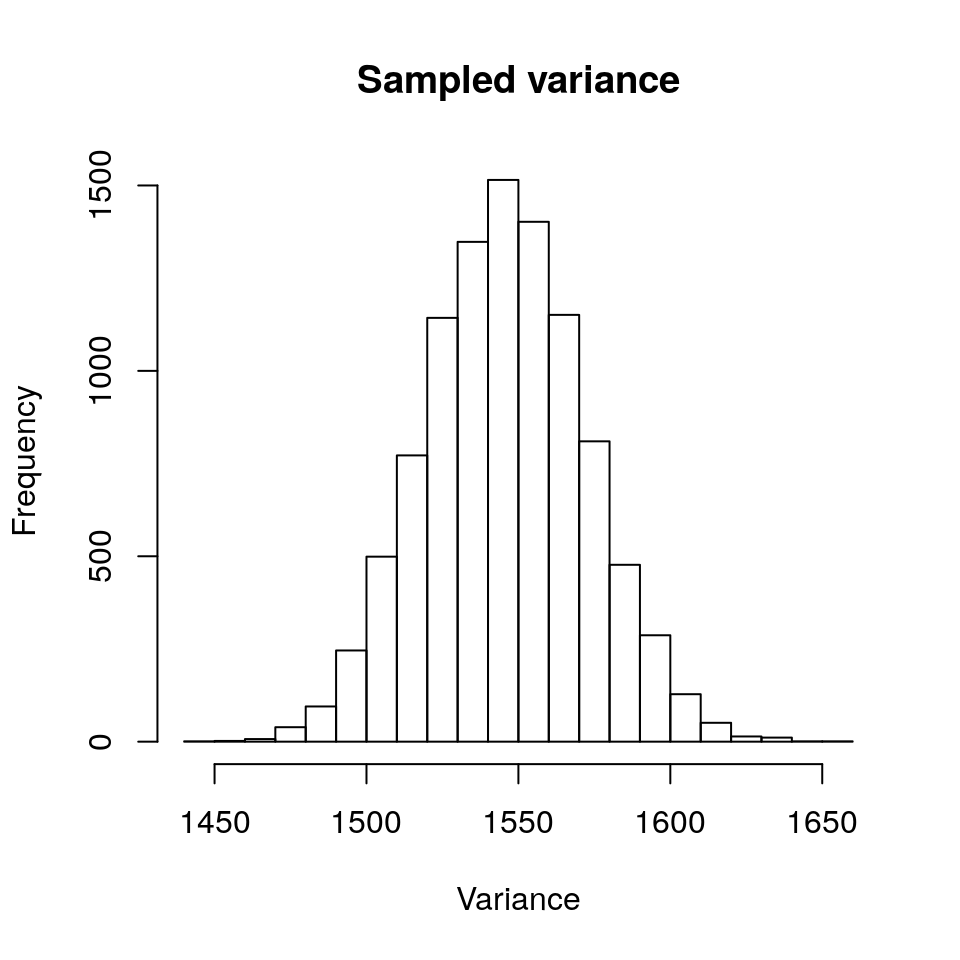

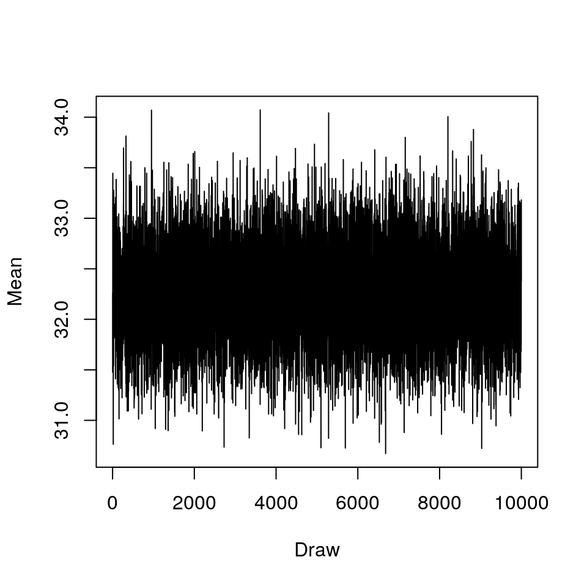

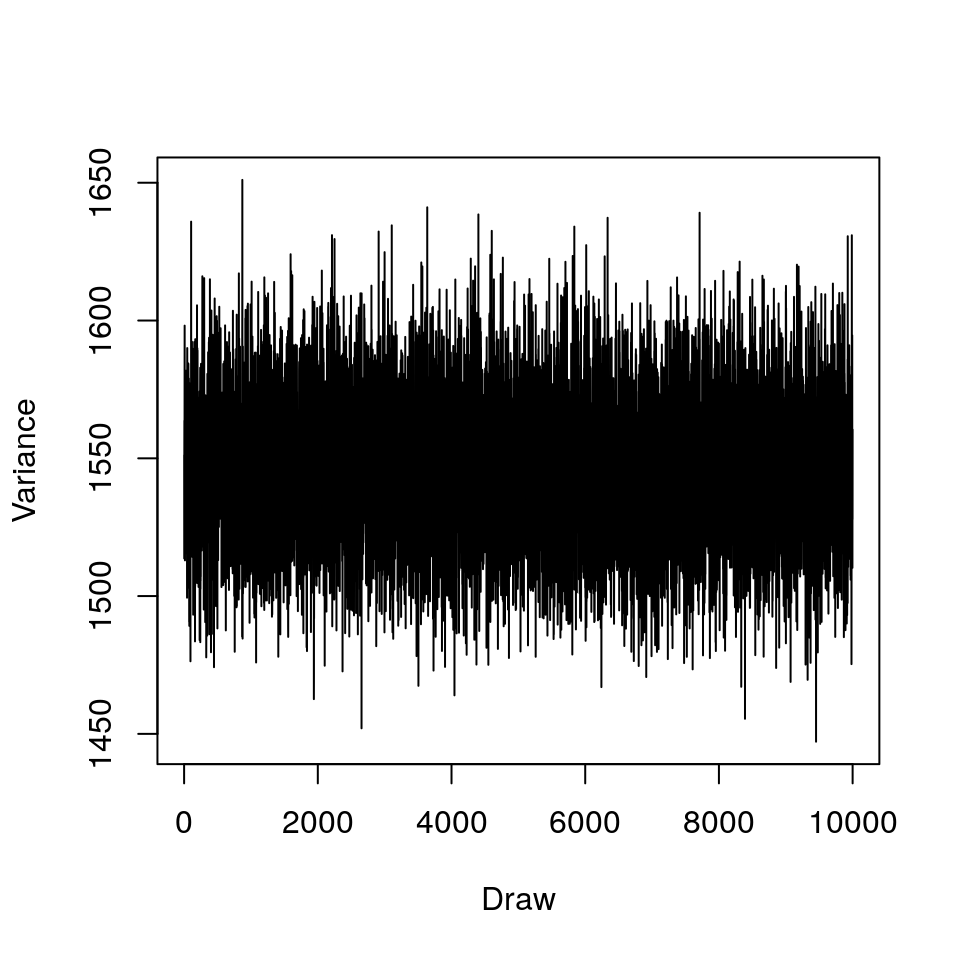

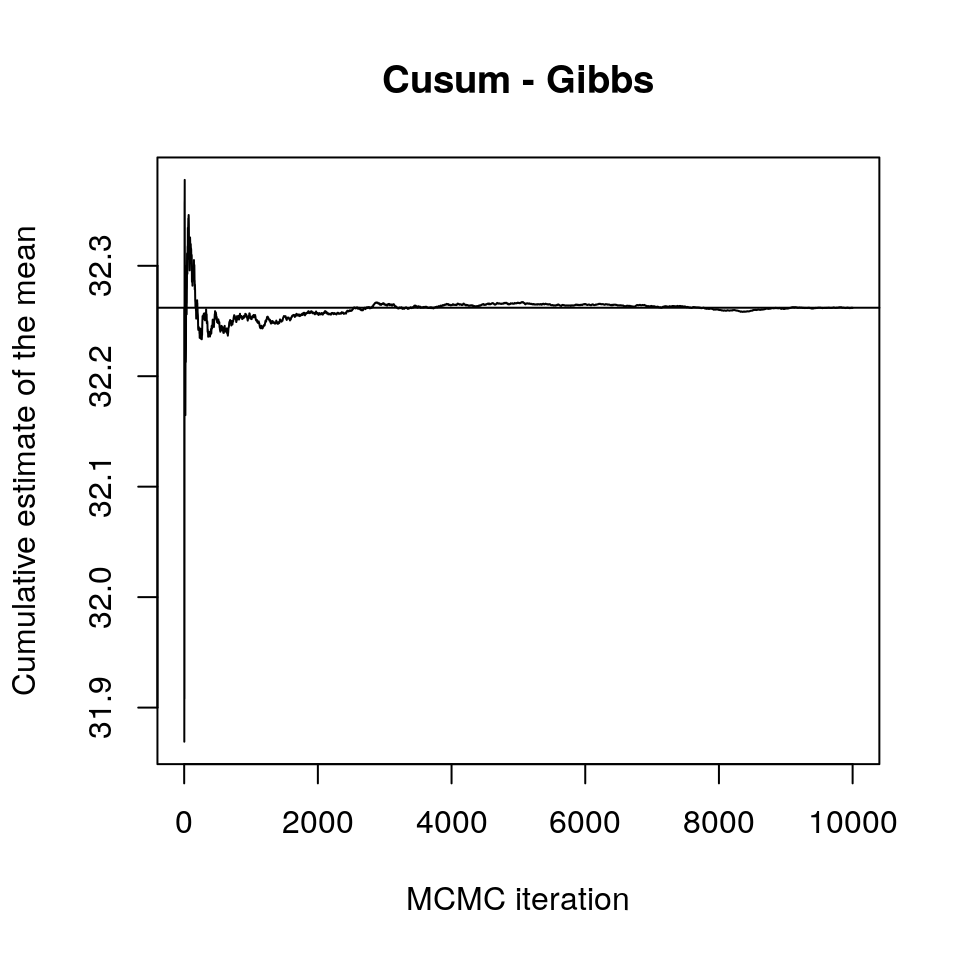

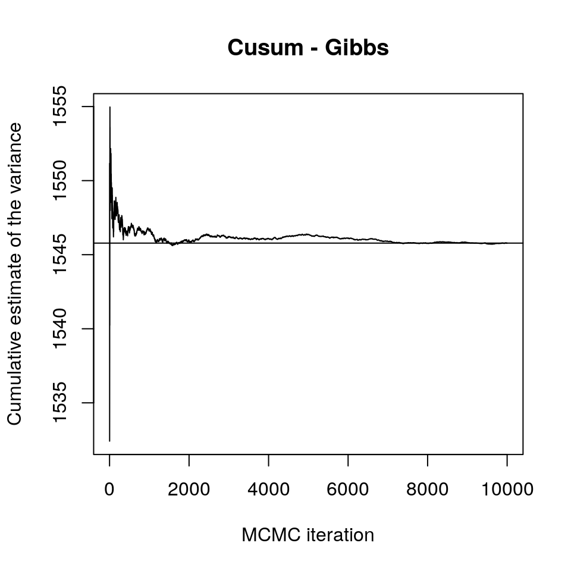

The plots show that the sampler converges. The first two plots of the trajectories shows that the different samples are not so correlated, which is good.

We then repeated the process but now the data followed a two-component mixture of normals model. The code was given, we only extended it so we could show the convergence of the sampler. Below are some plots showing the reults from the sampler with the convergence for the different parameters. We can see that perhaps the first 100 iterations can be seen as the burn-in period.

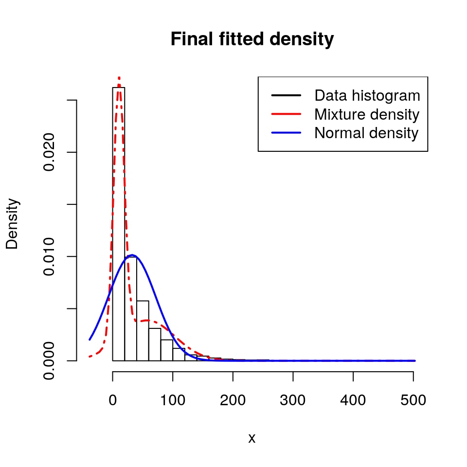

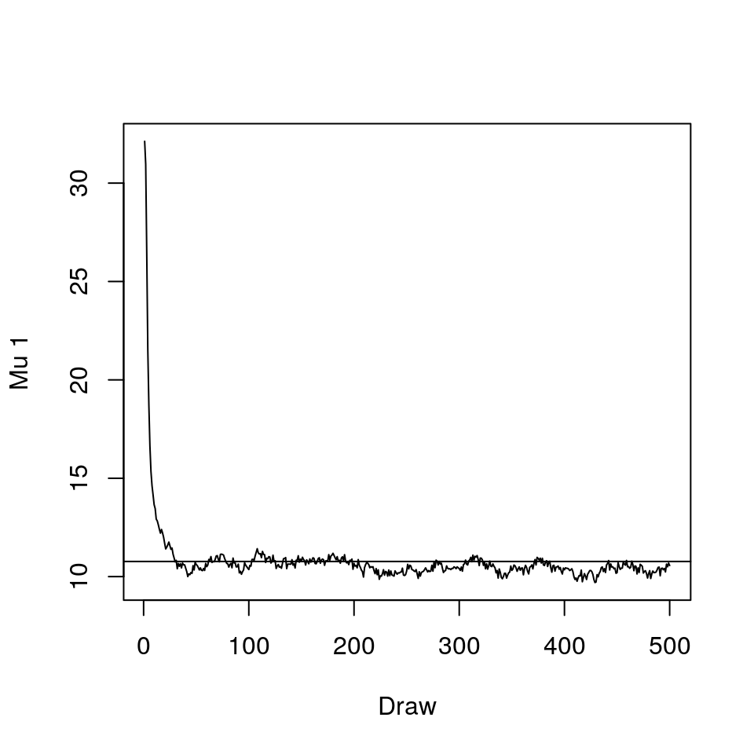

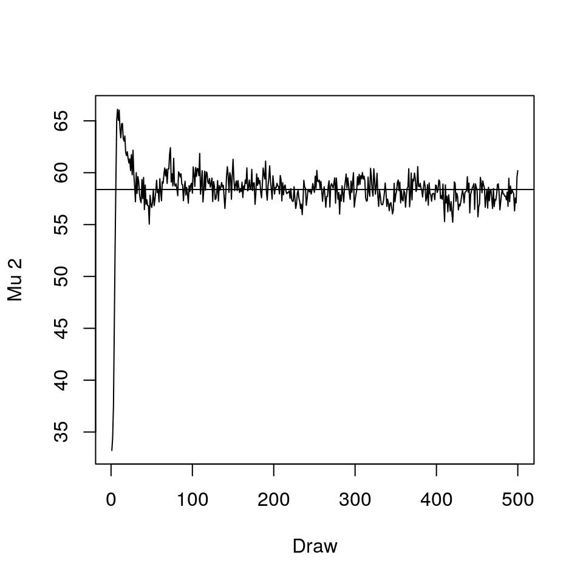

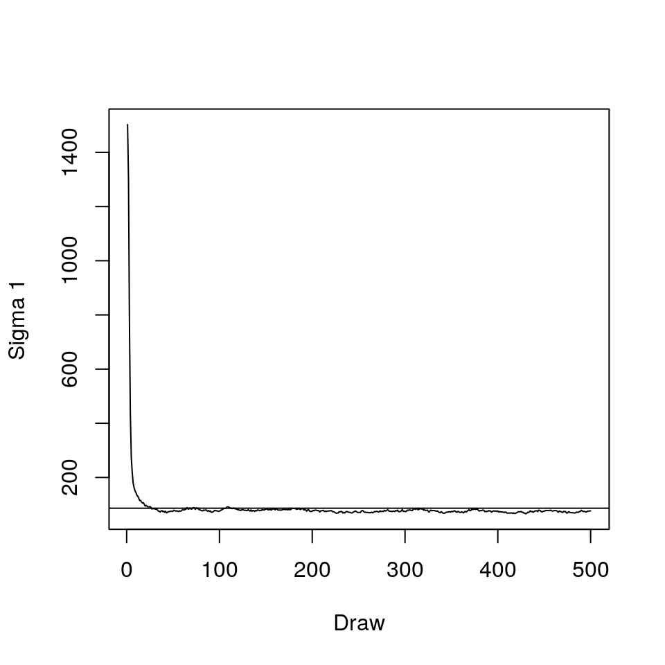

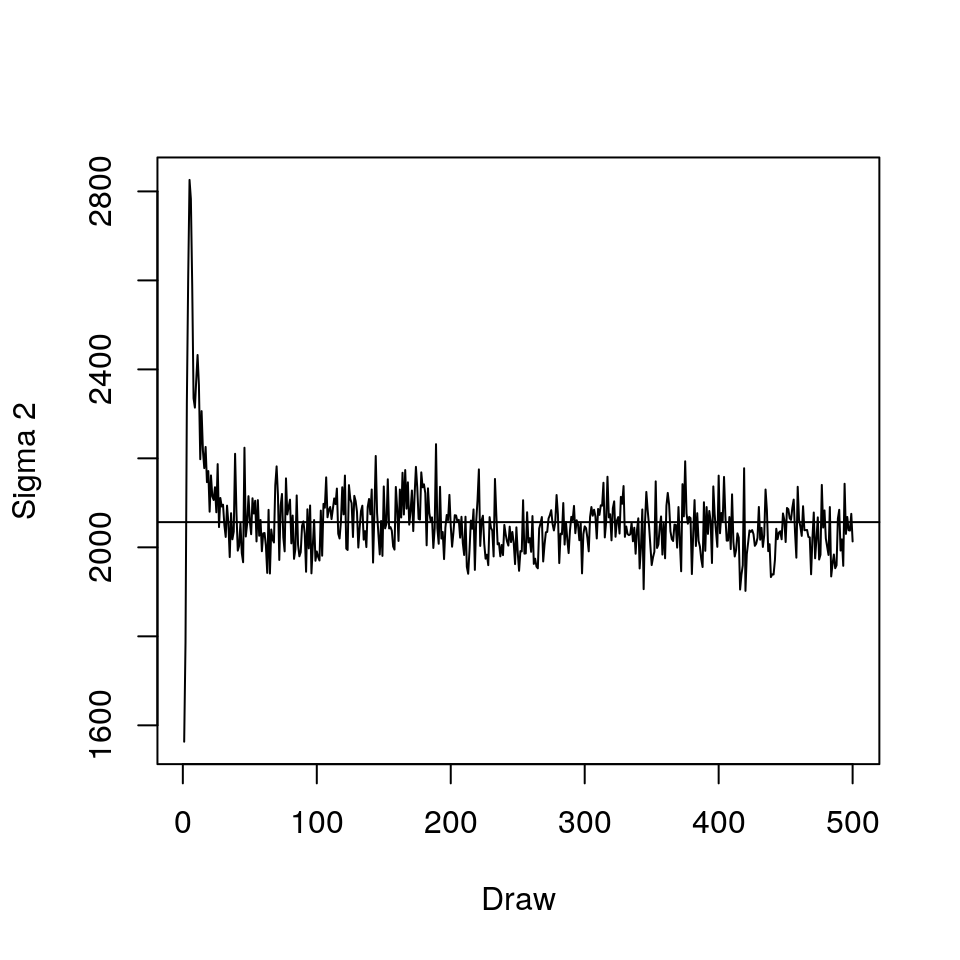

Below is a graphical comparison between the denisty of the data, the sampled normal density from above aswell as the sampled mixture of normals.

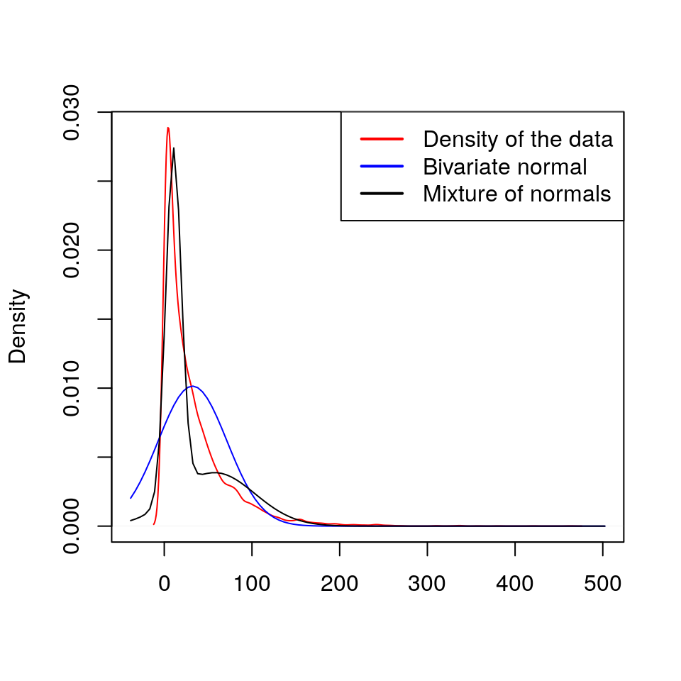

# Assignment 2

### Metropolis Random Walk for Poisson regression

In this assignment we considered the following poisson regression model $y_i|\beta \sim Poisson[exp(x_i^T\beta)], i = 1,..,n$ where $y_i$ is the count for the $i$th observation in the sample and $x_p$ is the p-dimensional vector with covariates. A data set conatining observations from 1000 eBay auctions of coins were given. The target variable in this assignment was the number of bids in each auction.

First a general linear model was fitted using the glm function in R. From this model we could se that the covariates Sealed, VerifyId and MinBidShare were the most significant.

Now we did a Bayesian analysis of the Poisson regression. The prior was $\beta \sim \mathcal{N}[0,100*(X^TX)^{-1}]$ where $X$ is the $n \times p$ covariate matrix. The posterior density was assumed to be approximately multivariate normal: $\beta|y \sim \mathcal{N}(\tilde\beta,J_y^{-1}(\tilde\beta))$. $\tilde\beta$ and $J_y(\tilde\beta)$ were computed with the optim function in R with the log posterior function of the Poisson model. Below the coefficients from the Bayesian analysis with optim is compared to the coefficients of the glm model, as we can see, they are very similar.

#### Bayesian analysis

```
## [1]  1.07235230 -0.02033338 -0.39274453  0.44366399 -0.05220897 -0.22145707
## [7]  0.07033797 -0.12041259 -1.89392696
```

#### GLM model

```
##       Const PowerSeller    VerifyID      Sealed     Minblem     MajBlem
##  1.07244206 -0.02054076 -0.39451647  0.44384257 -0.05219829 -0.22087119
##     LargNeg     LogBook MinBidShare
##  0.07067246 -0.12067761 -1.89409664
```

Finally, we simulated from the actual posterior of $\beta$ using the Metropolis algorithm. Our proposal density was $\theta_p|\theta^{(i-1)} \sim \mathcal{N}(\theta^{(i-1)},c\sum)$, where $\sum = J_y^{-1}(\tilde\beta)$ was obtained from the optim function. The value c is a tuning parameter, we used $c = 2$ in this assignment. When simulating with the metropolis algorithm using the same log posterior mentioned above, we got the following convergence curves for the different covariates. The samples does seem a bit corelated, but the result seems good still.

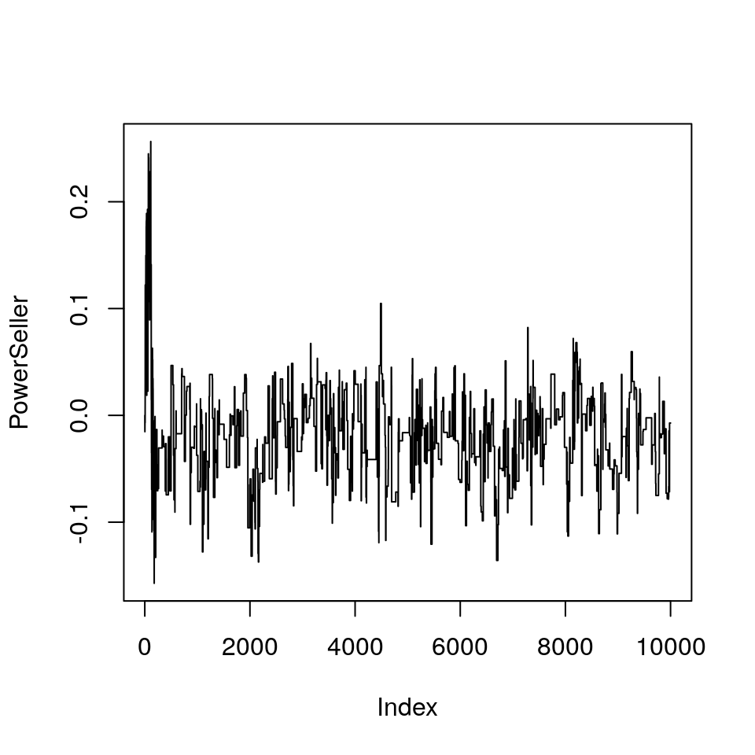

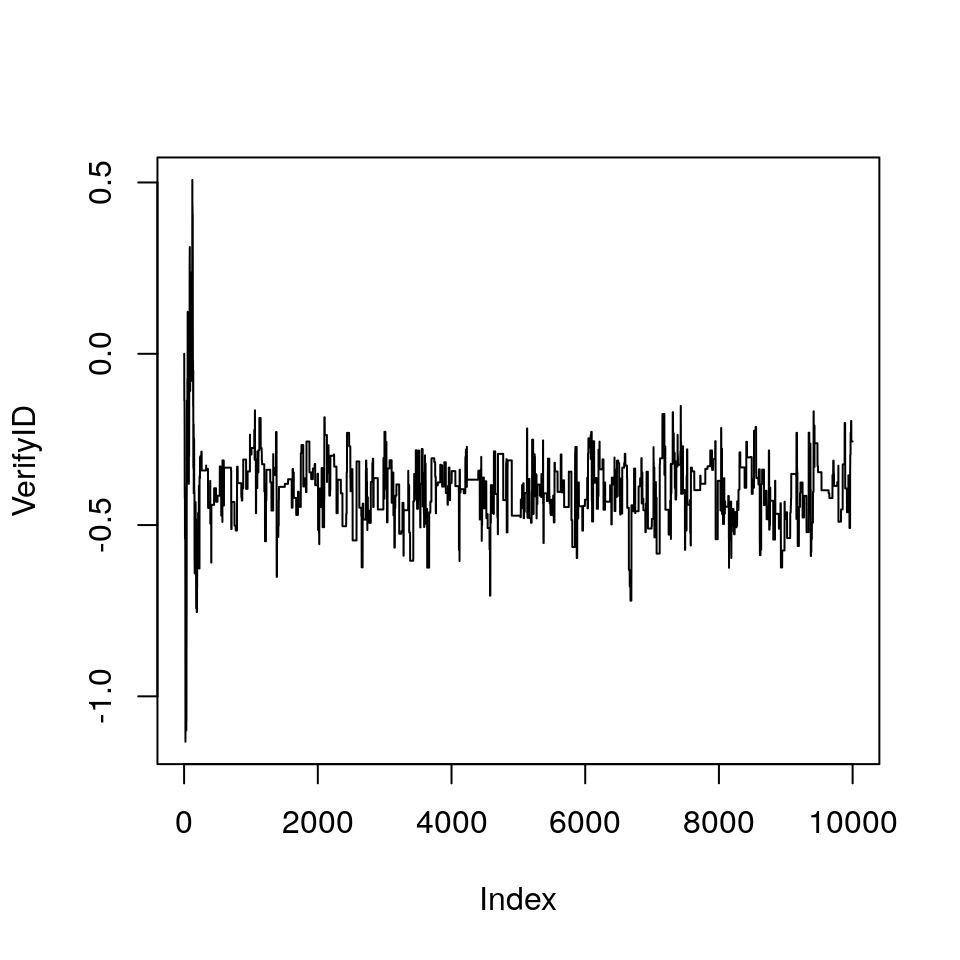

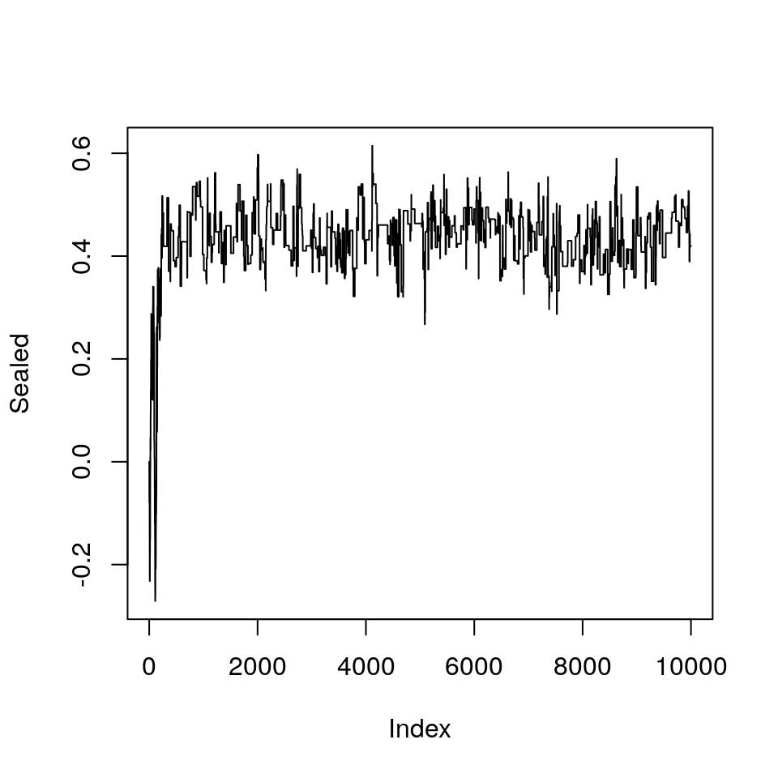

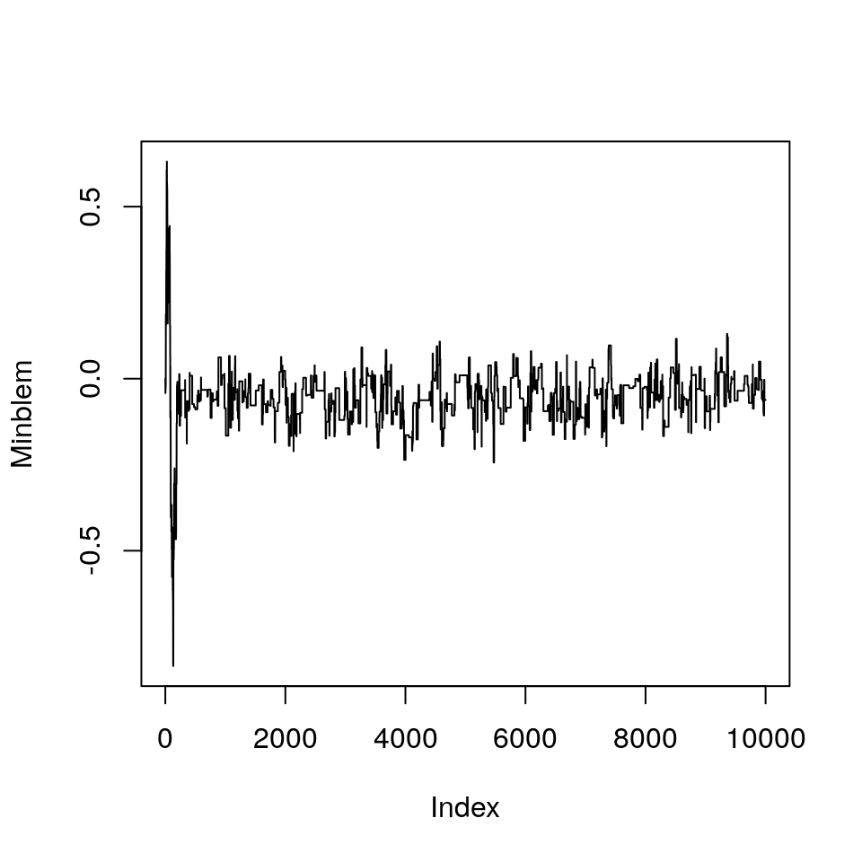

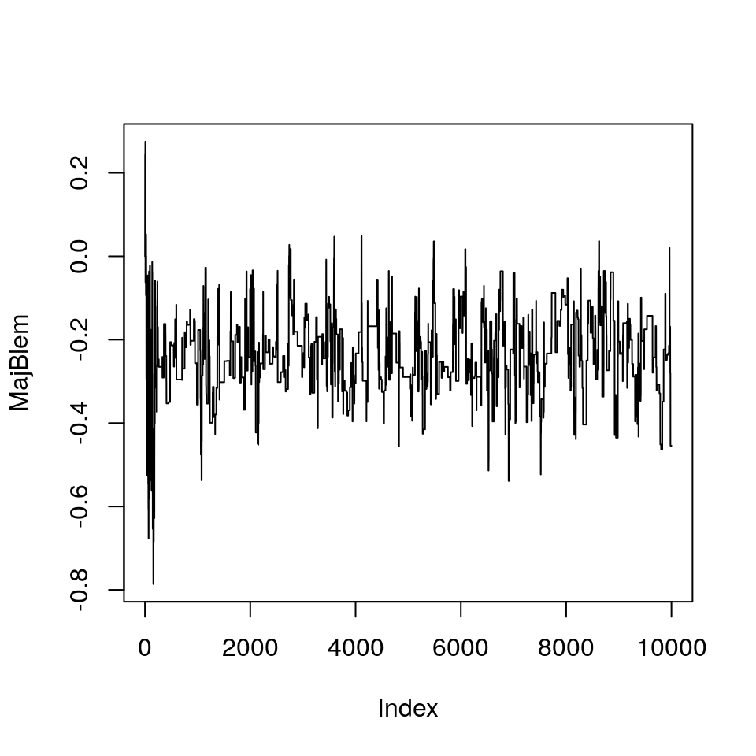

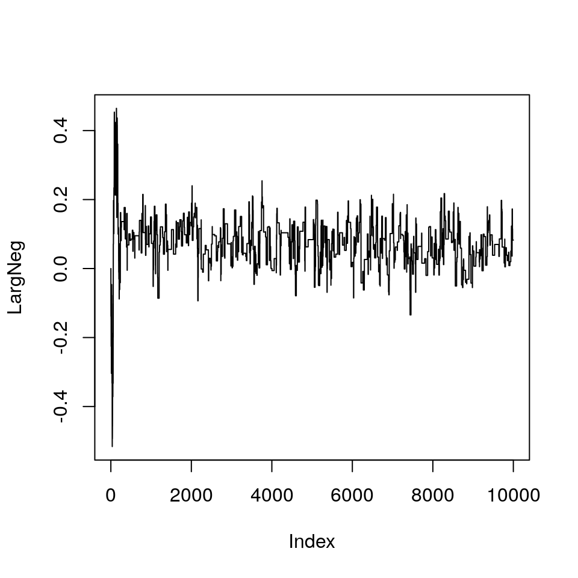

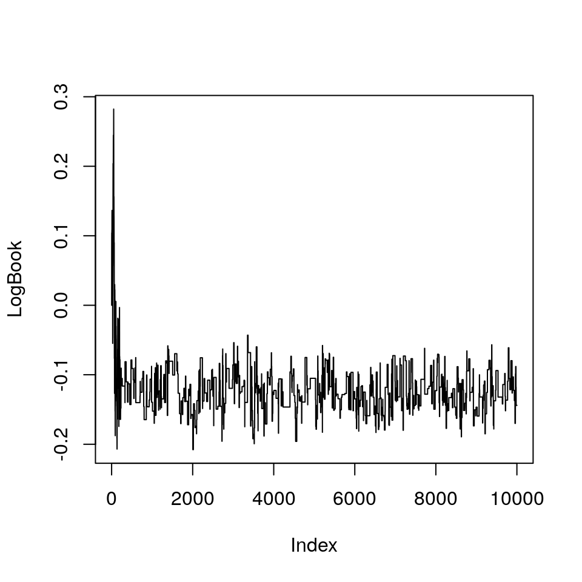

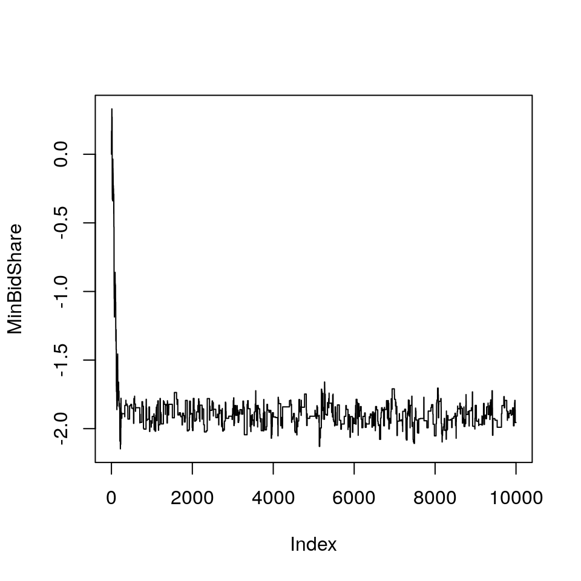

Here we also notice that perhaps the first 1000 iterations can be seen as the burn-in.

And we got the following values for the coefficients, which does not differ much from when using optim in the bayesian analsys.

#### Metropolis algorithm

```
## [1]  1.06104095 -0.01993666 -0.39559328  0.43507861 -0.05283118 -0.23656841
## [7]  0.07295384 -0.12145117 -1.88318986
```